# Análisis mundial de los gastos gubernamentales entre los años 2000 y 2021

Sofía Travieso García

[figure not shown]

[Cuadro de mandos](http://10.22.143.222:3838/sample-apps/a2559/Proyecto_Personal_Dashboard.Rmd)

# 1 Estado Actual y objetivos

El gasto gubernamental es un factor determinante en el desarrollo de cualquier país, ya que establece las bases para mejorar la calidad de vida de los ciudadanos y afrontar desafíos globales como la pobreza, el cambio climático, la defensa y la educación. A nivel global, los gobiernos enfrentan un entorno complejo, marcado por crisis económicas recurrentes, la creciente urbanización, y problemas ambientales de magnitud global. En este contexto, el análisis del gasto público es crucial para entender cómo los países están respondiendo a estos desafíos y cómo sus inversiones están alineadas con los [Objetivos de Desarrollo Sostenible (ODS)](https://www.pactomundial.org/que-puedes-hacer-tu/ods/?gad_source=1&gclid=Cj0KCQiAlsy5BhDeARIsABRc6ZvoBGVKkwI_ZqnGk1wEGjBF9Dfg5VtCGAZJI6X8L_Kh2gKFyHR9udwaAmdlEALw_wcB) de la [ONU](https://www.un.org/es/).

Los [ODS](https://www.pactomundial.org/que-puedes-hacer-tu/ods/?gad_source=1&gclid=Cj0KCQiAlsy5BhDeARIsABRc6ZvoBGVKkwI_ZqnGk1wEGjBF9Dfg5VtCGAZJI6X8L_Kh2gKFyHR9udwaAmdlEALw_wcB), establecidos en 2015 por las [Naciones Unidas (ONU)](https://www.un.org/es/), son un llamado global a la acción para mejorar la vida de las personas y proteger el planeta, estableciendo 17 objetivos que abarcan desde la erradicación de la pobreza hasta la lucha contra el cambio climático. Cada país, dependiendo de su contexto económico, social y político, tiene diferentes prioridades a la hora de asignar sus recursos, pero todos comparten la responsabilidad de contribuir a estos objetivos.

En la actualidad, los gastos gubernamentales se han visto afectados por crisis recientes, como la pandemia de COVID-19, lo que ha obligado a muchos gobiernos a reorientar sus presupuestos. Por ejemplo, la necesidad de mejorar la infraestructura sanitaria y el acceso a servicios médicos ha adquirido una nueva urgencia, lo que ha desviado fondos hacia la salud pública en detrimento de otras áreas.

En este contexto, el análisis de los gastos gubernamentales se hace esencial para evaluar la efectividad de las políticas públicas y su alineación con los [ODS](https://www.pactomundial.org/que-puedes-hacer-tu/ods/?gad_source=1&gclid=Cj0KCQiAlsy5BhDeARIsABRc6ZvoBGVKkwI_ZqnGk1wEGjBF9Dfg5VtCGAZJI6X8L_Kh2gKFyHR9udwaAmdlEALw_wcB). Es fundamental comprender cómo las inversiones en áreas específicas están contribuyendo al desarrollo económico y social, y cómo pueden ajustarse para alcanzar los objetivos globales de manera más eficiente y equitativa.

Con el propósito de comprender en profundidad cómo los recursos públicos están siendo distribuidos y utilizados en sectores clave, este trabajo se enfoca en los siguientes objetivos:

1. Realizar un análisis exhaustivo del gasto público en los sectores clave mencionados, con el fin de comprender cómo estos recursos están siendo asignados.
2. Evaluar la sostenibilidad de las políticas gubernamentales a largo plazo, considerando las crisis recientes y los desafíos emergentes, y analizar cómo las prioridades de inversión afectan el bienestar social y la equidad en el acceso a servicios esenciales para las poblaciones vulnerables.

# 2 Aportaciones

Es evidente que las decisiones gubernamentales influyen profundamente en el bienestar social y la estabilidad económica de los países. En un contexto global caracterizado por crisis económicas, desastres naturales y emergencias sanitarias, comprender cómo se asignan los recursos en sectores fundamentales es esencial. Este estudio tiene como objetivo proporcionar una visión clara de cómo los gobiernos han distribuido sus gastos a lo largo del tiempo, teniendo en cuenta factores como las crisis pasadas y los desafíos emergentes. Al analizar estos datos, se busca entender cómo las prioridades de inversión han variado en respuesta a situaciones específicas. Así, el proyecto no solo ofrece un análisis del estado actual de estos sectores, sino también una reflexión sobre las decisiones tomadas en diferentes contextos, lo que puede ser crucial para mejorar la asignación futura de recursos y promover una gestión más equitativa y sostenible.

Este proyecto se alinea con los [Objetivos de Desarrollo Sostenible (ODS)](https://www.pactomundial.org/que-puedes-hacer-tu/ods/?gad_source=1&gclid=Cj0KCQiAlsy5BhDeARIsABRc6ZvoBGVKkwI_ZqnGk1wEGjBF9Dfg5VtCGAZJI6X8L_Kh2gKFyHR9udwaAmdlEALw_wcB) propuestos por la [ULPGC](https://www.ulpgc.es/) para los Trabajos de Fin de Grado, ya que explora cómo los gastos públicos contribuyen al progreso hacia un desarrollo más inclusivo y sostenible. Al analizar áreas como Salud, Educación, Defensa y Protección del Medio Ambiente, se aborda directamente el impacto de las políticas públicas en varios [ODS](https://www.pactomundial.org/que-puedes-hacer-tu/ods/?gad_source=1&gclid=Cj0KCQiAlsy5BhDeARIsABRc6ZvoBGVKkwI_ZqnGk1wEGjBF9Dfg5VtCGAZJI6X8L_Kh2gKFyHR9udwaAmdlEALw_wcB) relevantes, tales como:

1. ODS 3: Salud y bienestar, al evaluar las inversiones en sistemas de salud.
2. ODS 4: Educación de calidad, al analizar los recursos destinados a mejorar la infraestructura educativa y la calidad del aprendizaje.
3. ODS 16: Paz, justicia e instituciones sólidas, al analizar los gastos en defensa y su relación con la seguridad nacional y la estabilidad global.
4. ODS 13: Acción por el clima.
5. ODS 15: Vida de ecosistemas terrestres, considerando el gasto en protección ambiental y su relación con la sostenibilidad.

Esta investigación, por tanto, analiza los gastos gubernamentales de forma anual en cuatro atributos numéricos clave: Defensa, Salud, Educación y Protección del Medio Ambiente entre los años 2000 y 2021.

## 2.1 Defensa

El gasto en defensa es crucial para la seguridad y soberanía de cualquier país, así como para mantener la estabilidad interna y externa. Este tipo de inversión no solo incluye el gasto en fuerzas armadas, equipos bélicos y sistemas de defensa, sino también en inteligencia, seguridad nacional, y la preparación para enfrentar amenazas externas o internas. El análisis de los gastos en defensa es clave para entender cómo los gobiernos priorizan la seguridad nacional frente a otros sectores, como la salud o la educación, y cómo este gasto se adapta a las nuevas amenazas globales, como el terrorismo, los ciberataques y las tensiones geopolíticas.

## 2.2 Salud

La inversión en salud pública es una prioridad para cualquier gobierno que busque garantizar el bienestar y la longevidad de su población. El gasto en salud incluye no solo la provisión de servicios médicos y hospitales, sino también la prevención de enfermedades, campañas de vacunación, investigación médica y la preparación ante emergencias sanitarias, como la reciente pandemia de COVID-19. Un análisis detallado del gasto en salud permite observar cómo se distribuyen los recursos en función de las necesidades de la población, las tasas de enfermedades y los riesgos emergentes. Además, el gasto en salud está directamente relacionado con el Objetivo de Desarrollo Sostenible 3 de la [ONU](https://www.un.org/es/), que busca garantizar vidas saludables y promover el bienestar de todas las personas.

## 2.3 Protección del medio ambiente

La protección del medio ambiente se ha convertido en una de las áreas más relevantes para los gobiernos en las últimas décadas, debido al aumento de los problemas ambientales como el cambio climático, la pérdida de biodiversidad y la contaminación. Los gastos en este sector incluyen inversiones en conservación de ecosistemas, manejo de residuos, control de la contaminación y mitigación del cambio climático. Estos esfuerzos son esenciales no solo para preservar los recursos naturales y reducir los impactos negativos en el ambiente, sino también para asegurar una mejor calidad de vida para las generaciones futuras. Este tipo de gasto también apoya varios [ODS](https://www.un.org/es/), en particular el ODS 13, que se enfoca en la acción por el clima, y el ODS 15, que promueve la vida de ecosistemas terrestres.

## 2.4 Educación

La educación es un sector clave para el desarrollo de cualquier nación, ya que proporciona a los ciudadanos las habilidades y conocimientos necesarios para participar activamente en la sociedad y en el mercado laboral. Las inversiones en educación incluyen desde el gasto en infraestructura escolar hasta el financiamiento de programas educativos, capacitación de docentes y desarrollo de nuevas tecnologías educativas. El análisis de los gastos en educación permite evaluar el compromiso de los gobiernos con el desarrollo de un capital humano cualificado y la reducción de las desigualdades. Este sector también está alineado con el ODS 4, que busca garantizar una educación inclusiva y de calidad para todos. La inversión en educación es, además, un motor para la innovación y el desarrollo económico a largo plazo.

# 3 Fuentes de los datos utilizados y análisis de su fiabilidad.

Para este estudio, los datos fueron obtenidos de la Conferencia de las [Naciones Unidas sobre Comercio y Desarrollo (UNCTAD)](https://unctad.org/es/statistics).

La [UNCTAD](https://unctad.org/es/statistics) es una agencia especializada de las Naciones Unidas que proporciona datos de alta calidad sobre el desarrollo económico global. Esta institución ofrece un enfoque riguroso y metodológico para la recolección de datos, lo que garantiza que la información publicada sea consistente y comparable entre países y a lo largo del tiempo. La elección de esta fuente responde a varios factores:

1. Cobertura amplia y actualizada: La base de datos incluye información de una gran cantidad de países a nivel mundial, lo que permite realizar comparaciones internacionales. Además, los datos abarcan un rango temporal extenso, desde el año 2000 hasta el 2021, lo que es esencial para evaluar tendencias a largo plazo.
2. Consistencia metodológica: Sigue metodologías estándares internacionales para la recopilación y clasificación de datos, como el [Sistema de Cuentas Nacionales (SNA)](https://unstats.un.org/unsd/nationalaccount/docs/SNA2008Spanish.pdf) y los manuales del FMI, lo que asegura una coherencia en la información proporcionada.
3. Acceso y disponibilidad: Los datos son accesibles públicamente a través de la plataforma de estadísticas de la [UNCTAD](https://unctad.org/es/statistics), lo que facilita la verificación y permite el análisis independiente.

# 4 Análisis exploratorio inicial

Esta es una fase crítica en cualquier proyecto de análisis de datos, ya que permite familiarizarse con las características y la calidad de los datos antes de realizar un análisis más profundo.

## 4.1 Descripción General de las Tablas

Ambas tablas tienen el mismo formato, pero difieren en la unidad de medida:

1. Gasto en dólares (USD): Esta tabla presenta la cantidad absoluta invertida en cada sector, en términos de dólares estadounidenses, para cada país y cada año.

| Year | Total.function | Economy.Label | Defence | Health | Education | Environment.protection |
| --- | --- | --- | --- | --- | --- | --- |
| 2000 | 153122.633 | Australia | 8057.621 | 24071.984 | 23066.666 | 2051.800 |
| 2000 | 100682.792 | Austria | 1705.404 | 14053.707 | 10269.251 | 875.668 |
| 2000 | 116971.373 | Belgium | 2875.760 | 14863.604 | 13101.075 | 1866.436 |
| 2000 | 244151.943 | Brazil | 12469.521 | 25159.483 | 30618.750 | 710.650 |
| 2000 | 5693.389 | Bulgaria | 421.542 | 507.282 | 558.957 | 144.023 |
| 2000 | 1116.206 | China, Macao SAR | 0.000 | 146.853 | 172.883 | 27.256 |
| 2000 | 1579.531 | Croatia | 48.403 | 205.581 | 176.935 | 19.193 |
| 2000 | 3369.616 | Cyprus | 168.836 | 240.416 | 497.920 | 21.058 |
| 2000 | 25253.031 | Czechia | 1055.691 | 4192.659 | 2714.282 | 538.105 |
| 2000 | 86489.488 | Denmark | 2358.241 | 10979.515 | 10322.840 | 825.669 |

2. Gasto como porcentaje del PIB: Esta tabla presenta el gasto gubernamental en términos relativos, como un porcentaje del PIB del país, lo que permite comparar la magnitud del gasto con el tamaño de la economía nacional.

| Year | Economy.Label | Defence | Health | Education | Environment.protection |
| --- | --- | --- | --- | --- | --- |
| 2000 | Australia | 1.96606 | 5.87357 | 5.62827 | 0.50064 |
| 2000 | Austria | 0.86657 | 7.14112 | 5.21813 | 0.44495 |
| 2000 | Belgium | 1.21749 | 6.29269 | 5.54650 | 0.79018 |
| 2000 | Brazil | 1.90244 | 3.83852 | 4.67142 | 0.10842 |
| 2000 | Bulgaria | 3.18241 | 3.82970 | 4.21982 | 1.08729 |
| 2000 | China, Macao SAR | 0.00000 | 2.16783 | 2.55208 | 0.40235 |
| 2000 | Croatia | 0.22195 | 0.94269 | 0.81134 | 0.08801 |
| 2000 | Cyprus | 1.69466 | 2.41312 | 4.99775 | 0.21137 |
| 2000 | Czechia | 1.70759 | 6.78166 | 4.39037 | 0.87039 |
| 2000 | Denmark | 1.43657 | 6.68839 | 6.28836 | 0.50297 |

Columnas:

1. Año: El año de observación.
2. País: El nombre del país o región.
3. Gasto en Defensa: El gasto total en fuerzas armadas, equipamiento militar, seguridad nacional…
4. Gasto en Salud: El gasto total en salud pública, hospitales, prevención de enfermedades…
5. Gasto en Educación: El gasto total en educación, infraestructura educativa, programas de capacitación docente…
6. Gasto en Protección del Medio Ambiente: El gasto total en protección medioambiental.

## 4.2 Incidencias Encontradas en las Tablas

**Diferentes Unidades de Medida:**

Al trabajar con ambas tablas, se deben considerar las diferentes unidades de medida. Mientras que la tabla de dólares presenta los gastos en valores absolutos (USD), la tabla de porcentajes muestra los mismos gastos como una fracción del PIB. Esto implica que, al comparar datos entre las tablas, es necesario tener en cuenta que los gastos en dólares no siempre reflejan una imagen precisa de la proporción de recursos que un país dedica a cada sector. Por ejemplo, un país con un PIB bajo puede estar destinando una gran parte de su economía a salud o educación, aunque el gasto en dólares sea más bajo en comparación con un país con un PIB más alto.

**Problemas de Escalabilidad:**

Relacionado con el punto anterior, a pesar de que ambas tablas contienen datos globales, los valores de gasto en dólares pueden mostrar una imagen distorsionada cuando se comparan países con economías muy diferentes. Esto se debe a que los países con economías grandes (como EE. UU. o China) tendrán cifras absolutas mucho mayores, pero esto no significa necesariamente que estén invirtiendo más proporcionalmente. Por ello, al comparar el gasto en términos de PIB, se logra una mejor perspectiva de cómo cada país prioriza la asignación de recursos.

**Ausencia de Datos Completos en Algunos Países:**

Ambas tablas presentan ausencias de datos para ciertos países en años específicos, lo que puede generar vacíos en el análisis. Esta incidencia es más notoria en países en desarrollo, donde la recopilación de datos es menos constante o está sujeta a fluctuaciones económicas. En algunos casos, la falta de datos para un país en particular podría afectar las comparaciones entre países.

## 4.3 Conclusión del Análisis Inicial

El análisis exploratorio inicial de los datos ha revelado que, aunque las dos tablas proporcionan una visión valiosa sobre el gasto gubernamental en sectores clave, existen varios desafíos relacionados con la comparabilidad de los datos debido a las diferentes unidades de medida y a la presencia de datos faltantes o inconsistentes. A pesar de estas incidencias, se dispone de suficiente información para llevar a cabo un análisis detallado, siempre que se realicen los ajustes apropiados en la metodología y se consideren las limitaciones de los datos.

# 5 Identificación de los requisitos de procesamiento y generación de tablas

## 5.1 Tratamiento de Datos Faltantes (NA)

Ambas tablas contienen valores faltantes, los cuales serán identificados y eliminados para evitar que afecten el análisis o la visualización. Dado que los valores faltantes pueden distorsionar la integridad de los resultados, los valores NA serán eliminados de ambas tablas. Esta eliminación asegura que los análisis se basen únicamente en datos completos y consistentes.

## 5.2 Filtrado de Datos para la Generación de Gráficas

Debido a la abundancia de datos, se aplicará un proceso de filtrado de los datos antes de generar cualquier gráfica. Este filtrado se realizará con el objetivo de seleccionar subconjuntos representativos y mejorar la legibilidad de las visualizaciones.

Algunos criterios de filtrado comunes podrían incluir:

1. Selección de años clave: Puede ser útil centrarse en periodos específicos (por ejemplo, años clave de crisis económicas o eventos globales como la pandemia de COVID-19).
2. Selección de países representativos: En lugar de mostrar todos los países, se puede optar por mostrar un conjunto representativo de naciones, ya sea por su tamaño económico, su relevancia para el estudio, o por su diversidad geográfica.
3. Agrupación de datos: Para simplificar la visualización, se pueden agrupar algunos países en bloques, lo que facilita una mejor comprensión visual.

## 5.3 Normalización de los Datos o Escala Logarítmica

En casos donde los valores de gasto varíen considerablemente entre los países, se puede aplicar un proceso de normalización o cambio de escala a logaritmo para reducir el impacto de los valores extremos y mejorar la legibilidad de las gráficas.

- Normalización: Consiste en ajustar los datos para que todos los valores se encuentren en un rango común (por ejemplo, de 0 a 1), lo que facilita la comparación entre países con diferentes economías y tamaños.
- Escala Logarítmica: En algunos casos, especialmente cuando existen valores muy altos, aplicar una escala logarítmica puede ser útil para comprimir la distribución de los datos. Esto ayuda a mostrar de manera más clara las diferencias entre países con distintos niveles de gasto, sin que los valores extremos dominen la visualización.

# 6 Análisis Exploratorio

El análisis exploratorio de datos es un paso fundamental para cualquier proyecto de análisis de datos, ya que permite obtener una primera comprensión de los conjuntos de datos disponibles, identificar patrones, detectar posibles anomalías y generar hipótesis iniciales.

## 6.1 Contextualización del Gasto Gubernamental en 2021

Para iniciar el análisis exploratorio de los datos sobre gastos gubernamentales, es fundamental proporcionar una visión general que permita identificar rápidamente patrones globales y regionales. Dado que se cuenta con dos conjuntos de datos (gastos en valores absolutos y como porcentaje del PIB), se ha optado por realizar un primer análisis con mapas coropléticos que muestren el panorama global del gasto público en el año 2021, un año clave para la recuperación económica tras la pandemia de COVID-19. Esta estrategia permite ubicar visualmente a los países y establecer una línea base para los análisis posteriores.

El primero representa el total gastado por cada país en términos absolutos (en dólares estadounidenses) durante el año 2021. Este enfoque se centra en visualizar los volúmenes de gasto sin normalizar, lo que ofrece una imagen clara de la magnitud de los recursos asignados por las diferentes naciones. Al realizar este análisis, se espera observar ciertos patrones destacados:

Economías grandes como Estados Unidos, China, Japón y Alemania se proyectan como los países con los mayores gastos totales debido a sus economías de gran escala y su capacidad para movilizar recursos públicos masivos. Estos países probablemente dominen la visualización, dado que sus cifras absolutas superan significativamente a las de economías más pequeñas.

Para hacer el análisis más completo y obtener una visión más precisa, hemos decidido utilizar el último valor disponible para cada país. Esto permite incluir datos de aquellos países que, por diversas razones, no hayan reportado sus cifras exactas para 2021. De esta manera, logramos una representación más abarcadora y fiel de la distribución de los gastos, minimizando los vacíos de información y facilitando comparaciones más completas entre distintas naciones.

Propósito del mapa:

- Contextualización inicial: Facilitar la identificación de países con gastos elevados que, debido a su magnitud, tenderán a destacar en gráficos posteriores cuando se analicen datos en dólares. Esto es particularmente relevante para entender por qué ciertas economías aparecen recurrentemente como líderes en inversión absoluta, incluso si su proporción respecto al PIB es diferente.
- Referencia visual: Establecer una referencia visual y geográfica que nos ayude a interpretar rápidamente cómo se distribuyen los recursos públicos en el panorama global, preparando el terreno para el análisis sectorial detallado.

[interactive chart not shown]

El segundo mapa dinámico se enfoca en mostrar cómo cada país distribuye su gasto público en relación con su Producto Interno Bruto (PIB) para cada uno de los cuatro sectores clave: Defensa, Salud, Educación y Protección del Medio Ambiente, durante el año 2021. Esto permitirá no solo observar la magnitud del gasto, sino también comparar la prioridad que cada país da a cada uno de estos sectores en relación con su capacidad económica.

1. Defensa: El gasto en defensa puede variar considerablemente entre países. En economías grandes como Estados Unidos o China, el gasto en defensa representa una fracción considerable del PIB, debido a sus grandes presupuestos de seguridad y armamento. Por otro lado, países con economías más pequeñas o en desarrollo, como algunos en África o América Latina, pueden destinar una menor proporción de su PIB a este sector.
2. Salud: Tras la pandemia de COVID-19, muchos países han aumentado significativamente sus presupuestos en salud. Países con sistemas de salud más robustos, como los de Europa Occidental (Reino Unido, Francia, etc.), pueden dedicar un porcentaje moderado del PIB a salud. Sin embargo, algunos países en desarrollo, con sistemas de salud más débiles o con altos índices de pobreza, podrían estar destinando una mayor proporción de su PIB a mejorar la cobertura sanitaria y la infraestructura de salud pública.
3. Educación: El gasto en educación es un indicador clave de las prioridades de desarrollo humano de un país. En países desarrollados, es probable que el gasto en educación sea consistente y proporcionalmente bajo en relación con el PIB debido a sistemas educativos ya consolidados. Por otro lado, los países en desarrollo, con desafíos en la expansión de la educación y el acceso a la calidad educativa, pueden dedicar un porcentaje más alto de su PIB a este sector.
4. Protección del Medio Ambiente: El gasto en protección del medio ambiente ha ganado relevancia en las últimas décadas debido al aumento de la conciencia sobre el cambio climático y la sostenibilidad. Países con políticas medioambientales fuertes, como los países escandinavos (Suecia, Noruega, etc.), pueden destinar un porcentaje mayor de su PIB a la protección del medio ambiente, reflejando sus compromisos con los [ODS](https://www.pactomundial.org/que-puedes-hacer-tu/ods/?gad_source=1&gclid=Cj0KCQiAlsy5BhDeARIsABRc6ZvoBGVKkwI_ZqnGk1wEGjBF9Dfg5VtCGAZJI6X8L_Kh2gKFyHR9udwaAmdlEALw_wcB) y la sostenibilidad. En países más industrializados o con menos recursos, el gasto relativo puede ser más bajo.

Nuevamente optamos por utilizar los últimos valores disponibles de cada atributo para cada país. Esta decisión nos permite incluir la mayor cantidad de datos posible y ofrecer una representación más completa de cómo se distribuye el gasto público en relación con el Producto Interno Bruto (PIB).

Propósito del Mapa:

- Comparación Relativa: El uso del porcentaje del PIB como unidad de medida elimina las distorsiones causadas por la diferencia de tamaño económico entre los países. Esto permite una comparación más equitativa y ayuda a identificar qué países están haciendo un esfuerzo relativo mayor en cada uno de estos sectores, independientemente de su tamaño económico.
- Prioridades Nacionales: Este mapa proporciona una representación clara de cómo las prioridades de inversión varían según el tamaño de la economía, ayudando a identificar aquellos países que, a pesar de tener economías más pequeñas, destinan un porcentaje significativo de su PIB a sectores clave como salud o medio ambiente.
- Perspectiva del Impacto: El análisis del gasto en relación con el PIB también proporcionará una visión de cómo las políticas públicas de cada país están alineadas con los desafíos globales, como el cambio climático, la desigualdad educativa y el acceso a servicios de salud. Esto facilitará un análisis más profundo de la sostenibilidad y eficacia de las políticas gubernamentales en relación con sus capacidades económicas

[interactive chart not shown]

Para analizarlo en profundidad y ver los resutados de forma más visual, haremos un mapa de calor. Este mapa de calor muestra los gastos gubernamentales en porcentaje del PIB de los 25 países principales en las cuatro categorías específicas para el año 2021. Los países seleccionados corresponden a aquellos con mayor gasto total en estas áreas.

[interactive chart not shown]

## 6.2 Inversión relativa por sectores

Las gráficas de barras tienen como objetivo proporcionar un desglose más detallado del gasto en cada uno de los cuatro sectores clave en 2021, expresado como un porcentaje del PIB de cada país. Estas visualizaciones servirán para identificar los países que más han invertido en estos sectores en comparación con el tamaño de su economía, permitiendo destacar las diferencias en las prioridades de inversión a nivel global.

[interactive chart not shown]

Los países con mayor porcentaje de PIB destinado a defensa incluyen a Israel, Estados Unidos, Armenia, Azerbaijan y naciones de Europa del Este como Ucrania, Lituania y Estonia. También se encuentran Australia y varios países pequeños como Maldivas.

La alta inversión relativa de países como Israel, Armenia y Azerbaijan puede explicarse por su situación geopolítica, donde existen conflictos activos o tensiones regionales que justifican un mayor gasto en defensa.

Estados Unidos, a pesar de ser la economía más grande del mundo, sigue destinando una parte considerable de su PIB a defensa, lo que refuerza su papel como una de las principales potencias militares a nivel global.

La presencia de países de Europa del Este como Ucrania, Letonia y Rumania se alinea con las crecientes tensiones regionales y el [conflicto con Rusia](https://es.wikipedia.org/wiki/Invasi%C3%B3n_rusa_de_Ucrania), lo que ha llevado a estos países a reforzar significativamente sus presupuestos de defensa.

En el caso de países como Singapur, la inversión alta se debe a su enfoque en mantener una fuerza militar moderna y tecnológicamente avanzada como parte de su política de seguridad.

[interactive chart not shown]

Los países con mayor porcentaje del PIB destinado a salud en 2021 son principalmente naciones europeas desarrolladas como Austria, Reino Unido, Francia, Alemania, Dinamarca y Noruega, así como otras economías avanzadas como Japón y Canadá. Estos países se caracterizan por tener sistemas de salud públicos robustos y un alto nivel de gasto social.

El elevado gasto relativo en salud en estos países refleja un fuerte compromiso con el bienestar de sus ciudadanos y la necesidad de sostener sistemas de salud integrales que cubran a toda la población.

La pandemia de COVID-19 probablemente ha impulsado un aumento en la inversión en salud, especialmente en países como Reino Unido y Francia, donde se implementaron medidas intensivas de atención médica y vacunación masiva.

Es interesante observar la presencia de países más pequeños como Islandia y Eslovenia, lo que indica que, a pesar de sus economías más reducidas, asignan una parte significativa de su PIB a mantener servicios de salud de alta calidad.

[interactive chart not shown]

Los países que destacan por su inversión relativa en protección del medio ambiente incluyen Países Bajos, Bélgica, Japón, Noruega y varios países del sur de Europa como España, Italia y Portugal.

Los Países Bajos y Bélgica son líderes en la implementación de políticas ambientales, invirtiendo en proyectos de mitigación del cambio climático, gestión de residuos y energías renovables. Esto se refleja en su alta proporción de gasto relativo al PIB en este sector.

Países como Japón y Noruega también muestran una fuerte inversión en políticas de sostenibilidad y protección ambiental, enfocándose en reducir sus huellas de carbono y cumplir con los objetivos climáticos internacionales.

La presencia de países mediterráneos como España, Italia y Portugal podría estar relacionada con iniciativas de protección de sus ecosistemas naturales y gestión de recursos hídricos, que son esenciales en regiones con riesgos de desertificación y cambios climáticos.

Es notable ver países pequeños y medianos como Eslovaquia y Mauricio invirtiendo en la protección ambiental, lo que indica un enfoque creciente en la sostenibilidad incluso en economías de menor tamaño.

[interactive chart not shown]

En cuanto a la inversión relativa al PIB en educación, los países que destacan incluyen Islandia, Israel, Sudáfrica, Suecia y varias naciones europeas del este y norte como Estonia, Dinamarca, Finlandia y Letonia.

Países nórdicos como Islandia, Suecia y Dinamarca han mantenido históricamente altos niveles de inversión en educación, lo que se refleja en sus sistemas educativos avanzados y altos niveles de alfabetización y formación de capital humano.

La inclusión de Sudáfrica en la lista es significativa, ya que muestra un esfuerzo considerable para mejorar el acceso a la educación y reducir la desigualdad en un país con grandes disparidades socioeconómicas.

En Europa del Este, países como Estonia, Letonia y Moldavia han incrementado su gasto educativo, reflejando una tendencia hacia el desarrollo del capital humano como motor de crecimiento económico y competitividad.

Israel también aparece en la lista, posiblemente debido a su enfoque en la educación como un pilar clave para su desarrollo tecnológico y económico.

## 6.3 Tendencias Globales de Gasto Público por Sector

La siguiente gráfica muestra la mediana de los gastos en cada sector a lo largo de los años, lo que facilita la comparación de las tendencias entre los diferentes sectores. Proporciona una visión clara de cómo las prioridades de gasto público han evolucionado a lo largo de dos décadas, reflejando tanto el impacto de eventos económicos globales como de crisis específicas, como la pandemia de COVID-19. Esta visualización permite observar cómo los gobiernos han ajustado sus recursos en función de las necesidades emergentes de sus poblaciones y cómo las prioridades globales, como el cambio climático y la salud pública, han influido en la distribución del gasto.

[interactive chart not shown]

En términos generales, todas las líneas muestran una tendencia de crecimiento, aunque con algunas variaciones significativas, lo que sugiere un aumento en los presupuestos gubernamentales a medida que la economía global crecía y los gobiernos asumían nuevas responsabilidades en áreas clave como la salud, la educación, la defensa y el medio ambiente. Sin embargo, también se observan caídas en ciertos años, lo que podría reflejar ajustes fiscales o cambios en las prioridades políticas debido a crisis económicas o eventos imprevistos.

El gasto en **Salud** ha sido una de las áreas con mayor crecimiento en las últimas dos décadas, particularmente a partir de 2019, superando al sector de Educación. La pandemia de COVID-19 marcó un punto de inflexión, impulsando a los gobiernos a destinar recursos significativos a fortalecer sus sistemas de salud. Los aumentos en los presupuestos reflejan inversiones en infraestructura sanitaria, adquisición de equipos médicos, desarrollo de vacunas y programas de prevención. Este incremento acelerado destaca la creciente prioridad de los países en garantizar sistemas de salud robustos para hacer frente a emergencias sanitarias y mejorar la calidad de vida de sus poblaciones.

En el contexto previo a la pandemia, el gasto en salud ya mostraba una tendencia de crecimiento estable, impulsada por factores como el envejecimiento de la población y el aumento de enfermedades crónicas. Las políticas públicas en países desarrollados han apuntado a mejorar la accesibilidad y la calidad de los servicios de salud, reflejando una demanda constante de mayores inversiones en este sector. Sin embargo, a pesar de los incrementos, la variabilidad entre países es significativa, con naciones más desarrolladas invirtiendo mayores porcentajes del PIB en comparación con economías emergentes.

En cuanto a la **Educación**, aunque el gasto se ha mantenido en niveles elevados desde 2000, no ha mostrado el mismo incremento drástico que ha tenido el sector salud. A pesar de que la educación siempre ha sido un área prioritaria para los gobiernos, el gasto en este sector parece haber tenido un ritmo de crecimiento más estable y sostenido a lo largo de los años. El gasto en educación estuvo entre los más altos a principios de los 2000, alcanzando uno de sus puntos más altos alrededor de 2007-2008, antes de experimentar una desaceleración notable en comparación con la salud.

Es importante resaltar que entre 2004 y 2008 se observó un crecimiento drástico en el gasto en educación, lo que se puede atribuir a iniciativas globales como los Objetivos de [Desarrollo del Milenio](https://es.wikipedia.org/wiki/Objetivos_de_Desarrollo_del_Milenio) que impulsaron a muchos países a aumentar su inversión en educación. Este periodo también coincidió con un crecimiento económico global que permitió a varios gobiernos destinar mayores presupuestos a este sector. Sin embargo, después de 2008, este crecimiento se desaceleró, probablemente debido a la [crisis financiera](https://es.wikipedia.org/wiki/Crisis_financiera_de_2007-2008) global, que afectó los presupuestos de muchos países.

En los últimos años, el sector educativo ha tenido un crecimiento constante, aunque no con los mismos picos que otros sectores. Los gobiernos han seguido invirtiendo en educación, pero la necesidad de adaptarse a los avances tecnológicos y la digitalización de la enseñanza ha hecho que la inversión en infraestructura educativa se vuelva aún más crucial. La incorporación de nuevas tecnologías en el aula requiere de una mayor inversión, tanto en dispositivos como en formación para docentes y alumnos, lo que explica la importancia de seguir invirtiendo en este ámbito.

El gasto en **Defensa** ha mostrado una tendencia de crecimiento moderado pero sostenido a lo largo de las dos últimas décadas. Este sector se ve fuertemente influenciado por el contexto geopolítico y de seguridad global, con ligeros aumentos observados durante períodos de inestabilidad o conflictos internacionales. Entre 2002 y 2005, se observó el primer pico, influenciado por el contexto posterior a los atentados del 11 de septiembre de 2001 y el inicio de las guerras en Afganistán e Irak. Durante este periodo, muchos países aumentaron su inversión en defensa como respuesta a las nuevas amenazas del terrorismo internacional y para apoyar operaciones militares en Oriente Medio.

El segundo repunte ocurrió en 2007-2008, coincidiendo con el aumento de tensiones internacionales y la necesidad de modernizar equipos militares en varias naciones. La expansión militar de Rusia y las preocupaciones sobre la estabilidad en regiones como el Cáucaso también impulsaron a los países occidentales a incrementar sus presupuestos en defensa. Posteriormente, entre 2016 y 2017, se observó otro aumento, relacionado con eventos como la anexión de Crimea por Rusia en 2014, que generó una respuesta significativa de los países de la OTAN, incrementando sus gastos en defensa para reforzar sus capacidades militares en Europa del Este.

Finalmente, el periodo de 2019 a 2021 muestra un nuevo pico, marcado por varias razones. La intensificación de rivalidades geopolíticas, como las tensiones entre Estados Unidos y China, así como los conflictos en el Medio Oriente y el aumento de las capacidades nucleares de varios países, llevaron a un incremento significativo en los presupuestos de defensa. Además, las tensiones en Europa del Este, incluyendo la situación en Ucrania antes de la invasión rusa de 2022, también motivaron a los gobiernos a aumentar sus gastos militares para prepararse ante posibles escenarios de conflicto, evidenciando la creciente preocupación por la seguridad y estabilidad global.

El gasto en **Protección del Medio Ambiente** ha mostrado un crecimiento moderado en comparación con otros sectores, manteniendo una tendencia ascendente pero sin alcanzar los mismos niveles de inversión que áreas como la salud o la educación. Este aumento refleja la creciente conciencia global sobre la necesidad de abordar el cambio climático y proteger los recursos naturales. En el periodo entre 2007 y 2011, se observa un ligero repunte en el gasto, probablemente impulsado por el interés renovado en la sostenibilidad y la implementación de políticas medioambientales más activas.

En 2015, el gasto en protección ambiental experimentó un nuevo incremento, coincidiendo con la firma del [Acuerdo de París](https://es.wikipedia.org/wiki/Acuerdo_de_Par%C3%ADs), un momento clave en el que los países se comprometieron a reducir sus emisiones de carbono y a fomentar inversiones en energías renovables y otras medidas sostenibles. Este acuerdo marcó un punto de inflexión en las políticas medioambientales de muchas naciones, llevando a un leve repunte en la inversión. No obstante, aunque el gasto ha mostrado cierta mejoría desde entonces, su crecimiento sigue siendo modesto en comparación con sectores más prioritarios, indicando que aún queda mucho por hacer para que la protección del medio ambiente reciba una inversión acorde a su importancia global.

Finalmente, en 2019, el gasto en Protección del Medio Ambiente inició un crecimiento más pronunciado. Este repunte coincide con un aumento en la conciencia pública sobre la crisis climática, impulsado en gran parte por movimientos sociales y activistas medioambientales, como [Greta Thunberg](https://es.wikipedia.org/wiki/Greta_Thunberg) y el movimiento [Fridays for Future](https://es.wikipedia.org/wiki/Fridays_For_Future). Las huelgas climáticas, junto con una mayor cobertura mediática sobre los efectos del cambio climático, llevaron a los gobiernos a prestar más atención a la demanda popular de acción climática y a incrementar sus presupuestos en políticas de protección ambiental.

[interactive chart not shown]

Este gráfico generado a partir de los datos de gastos de España en diferentes áreas (Defensa, Salud, Protección del Medio Ambiente y Educación) presenta la evolución anual de estas categorías entre los años disponibles. Utilizando un formato de series temporales, se visualiza cómo ha variado el gasto en cada sector a lo largo del tiempo, facilitando la comparación entre las distintas categorías. Al comparar esta serie con los datos globales, se observa que las tendencias en España siguen un patrón similar, aunque con algunas diferencias notables en los picos y caídas a lo largo de los años. Es evidente que los cambios en el gasto de España están alineados con los ciclos económicos y las decisiones políticas clave a nivel global. En particular, las fluctuaciones en el gasto reflejan momentos de crisis, como la [crisis financiera](https://es.wikipedia.org/wiki/Crisis_financiera_de_2007-2008) de 2008 o la pandemia de COVID-19, que tuvieron un impacto directo en las prioridades del gasto público del país. De igual manera, las decisiones internacionales, como los compromisos en sostenibilidad y los esfuerzos por mejorar la infraestructura de salud y defensa, también se reflejan en estos patrones. Este análisis destaca la relación directa entre los contextos internacionales y las decisiones presupuestarias de España, mostrando una tendencia global de adaptación a desafíos económicos, sociales y políticos.

## 6.4 Descomposición STL y predicción

Los gastos gubernamentales en salud han sido un área crítica de atención, particularmente en el contexto de la pandemia de COVID-19. Durante los años 2020 y 2021, los gobiernos de todo el mundo incrementaron significativamente sus presupuestos de salud para hacer frente a la emergencia sanitaria global. Este aumento se destinó a reforzar los sistemas de salud, financiar campañas de vacunación, ampliar la capacidad hospitalaria y adquirir equipos médicos esenciales.

En esta primera parte del análisis, presentamos una gráfica que muestra cómo han evolucionado los gastos en salud como porcentaje del PIB durante los años más críticos de la pandemia:

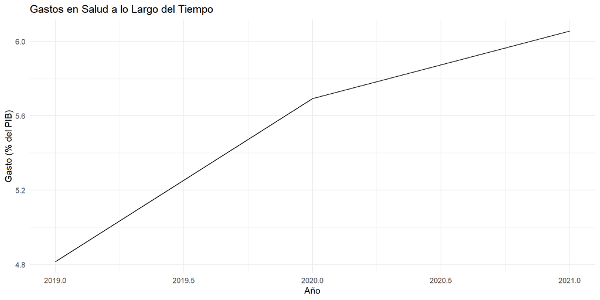

La gráfica muestra un aumento significativo en los gastos en salud durante 2020 y 2021, destacando la magnitud de los recursos destinados a mitigar los efectos de la pandemia. Este incremento es el reflejo de la necesidad urgente de los gobiernos de responder a la crisis sanitaria global.

Para comprender mejor la evolución de los gastos en salud, utilizamos la descomposición STL (Seasonal and Trend decomposition using Loess). Esta técnica nos permite separar la serie temporal en tres componentes:

Tendencia: Refleja los cambios a largo plazo en los gastos en salud.

Estacionalidad: Identifica patrones recurrentes que se repiten cada cierto periodo.

Residuos: Representa las fluctuaciones aleatorias o el ruido de la serie.

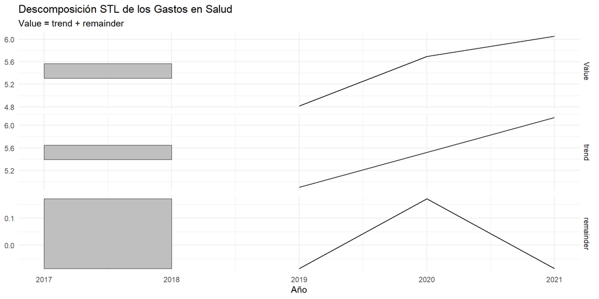

Mediante esta técnica, podemos observar cómo los gastos en salud en los últimos años han aumentado significativamente. Una vez que hemos descompuesto la serie temporal, el siguiente paso es modelar los datos para predecir el comportamiento futuro de los gastos en salud. El modelo ARIMA es una técnica ampliamente utilizada para predecir series temporales. ARIMA es eficaz para modelar datos que muestran dependencia temporal (es decir, que los valores pasados afectan a los valores futuros), lo que es frecuente en los gastos gubernamentales, ya que las políticas y decisiones de gasto se basan en tendencias y ciclos anteriores. Esto nos proporciona una estimación de cómo podrían evolucionar los gastos a medida que la pandemia de COVID-19 pase a un segundo plano y los gobiernos ajusten sus presupuestos a nuevas realidades económicas y sociales.

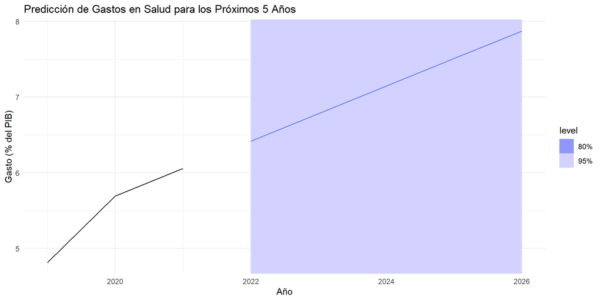

La predicción muestra una tendencia ascendente en los gastos en salud durante los próximos cinco años. Esto indica que, aunque la pandemia de COVID-19 podría disminuir en intensidad, los gobiernos continuarán destinando una proporción significativa de sus presupuestos al sector salud. Algunas posibles razones para este aumento son el fortalecimiento de los sistemas de salud para prevenir futuras crisis sanitarias, la inversión en investigación y desarrollo de vacunas y tratamientos y el aumento de los costos de atención médica debido a la demanda de servicios de salud más avanzados.

Los gastos gubernamentales en educación representan una inversión clave en el desarrollo económico y social de un país, ya que la educación es fundamental para la formación de capital humano, la reducción de la desigualdad y la promoción de la innovación. A diferencia de otros sectores como la salud, donde las fluctuaciones en el gasto pueden ser impulsadas por eventos extraordinarios como pandemias, los gastos en educación tienden a mostrar un comportamiento más estable y predecible, influenciado principalmente por políticas públicas a largo plazo y ciclos presupuestarios anuales.

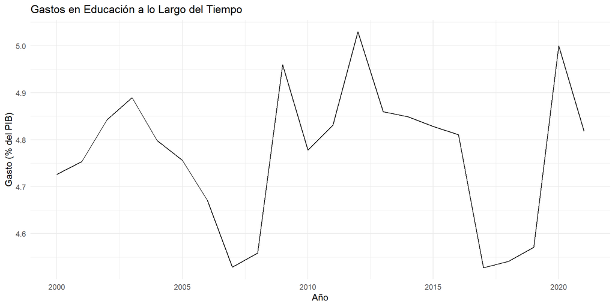

A partir de la gráfica proporcionada, podemos observar que los gastos presentan fluctuaciones significativas, aunque en general mantienen una tendencia moderadamente estable. Esto contrasta con sectores como la salud, donde las fluctuaciones tienden a ser más abruptas en respuesta a emergencias sanitarias, como la pandemia.

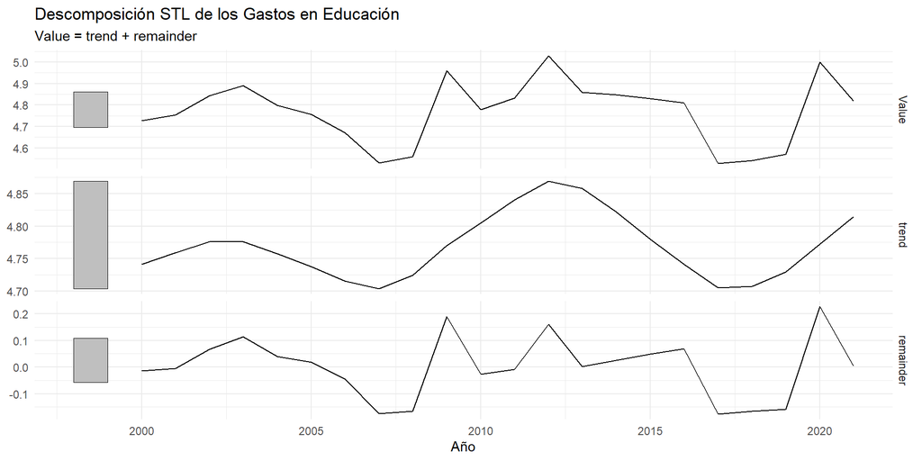

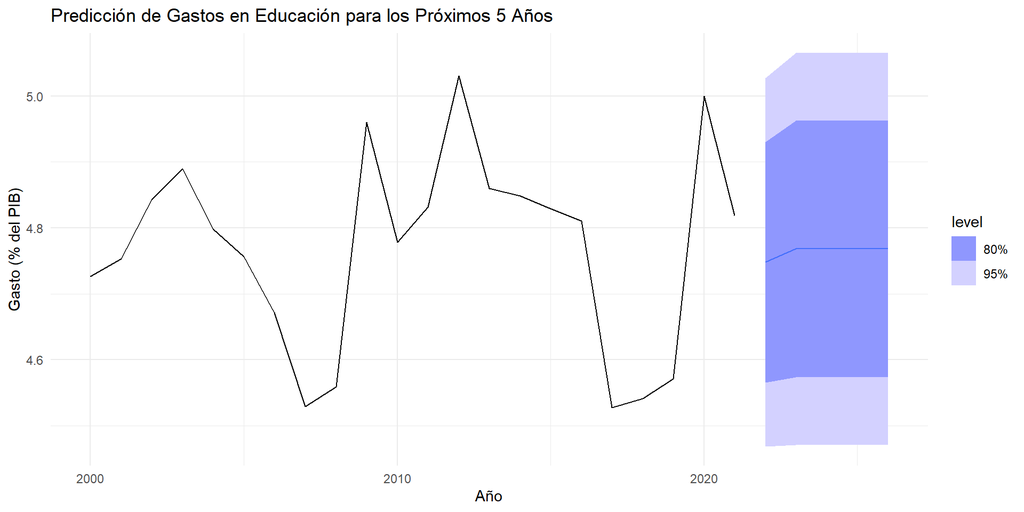

Los gastos en defensa son una parte crucial del presupuesto gubernamental, ya que están estrechamente vinculados con la seguridad nacional, las relaciones internacionales y las políticas de defensa. A diferencia de otros sectores como la salud o la educación, los gastos en defensa pueden verse influenciados por una variedad de factores, como conflictos militares, alianzas internacionales, cambios en la geopolítica y decisiones estratégicas de los gobiernos.

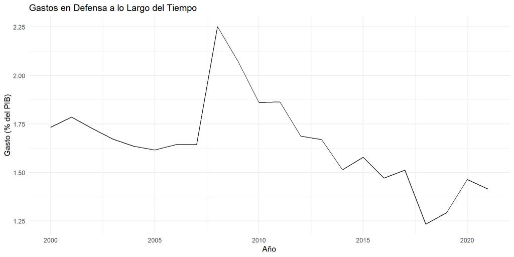

Al observar la serie temporal de los gastos en defensa, podemos identificar las fluctuaciones y cambios a lo largo del tiempo, reflejando posibles efectos de decisiones políticas, crisis internacionales, y cambios en la seguridad nacional.

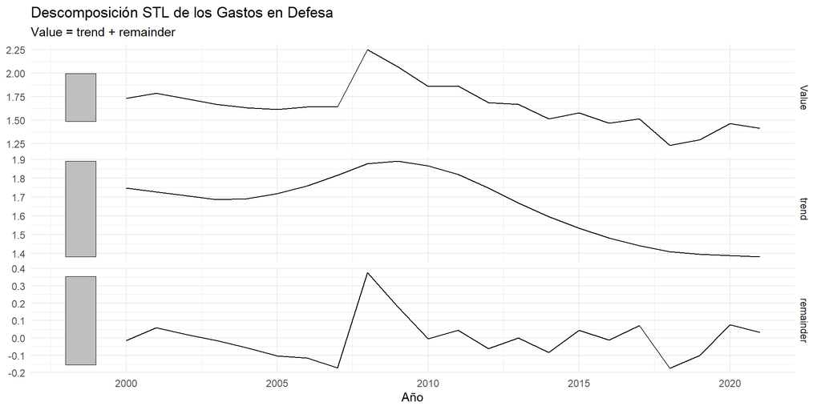

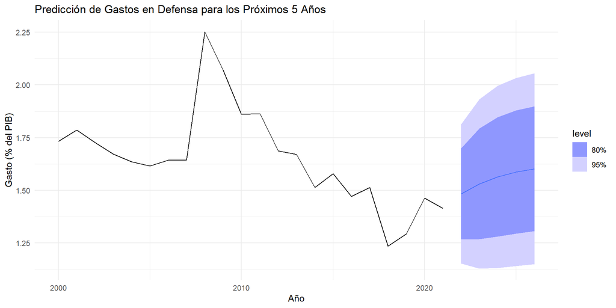

La predicción de los gastos en defensa utilizando el modelo ARIMA sugiere que se espera un aumento en los próximos años. Este incremento podría estar relacionado con varios factores, como el fortalecimiento de las políticas de seguridad, posibles tensiones geopolíticas o un ajuste en las asignaciones presupuestarias para reforzar la capacidad militar. Esto podría reflejar una priorización de la seguridad nacional en respuesta a dinámicas internacionales cambiantes.

La protección al medio ambiente es un tema de creciente relevancia en la agenda gubernamental global. Con el aumento de la conciencia sobre el cambio climático, la pérdida de biodiversidad y la contaminación, los países han comenzado a asignar más recursos para abordar estos desafíos ambientales. Los gastos en protección al medio ambiente incluyen inversiones en energías renovables, conservación de recursos naturales, programas de reciclaje y políticas para mitigar el impacto ecológico de diversas industrias. A diferencia de sectores como la defensa o la educación, los gastos en medio ambiente pueden estar influenciados por acuerdos internacionales, políticas ambientales y la evolución de las preocupaciones sobre el clima global.

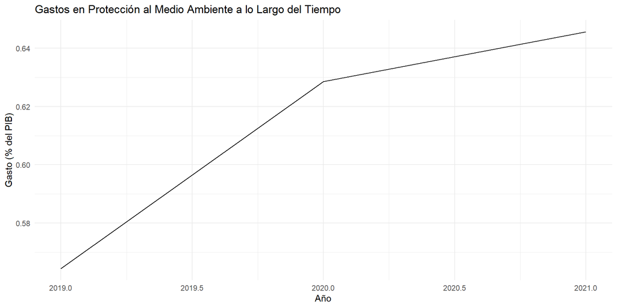

Al observar los últimos años en la serie temporal de gastos en protección al medio ambiente, podemos notar un crecimiento gradual, especialmente en respuesta a la creciente conciencia global sobre el cambio climático y las políticas medioambientales más estrictas. Esto refleja el aumento en las inversiones en áreas como energías renovables, conservación de la biodiversidad y reducción de emisiones, en línea con los compromisos de sostenibilidad de los países.

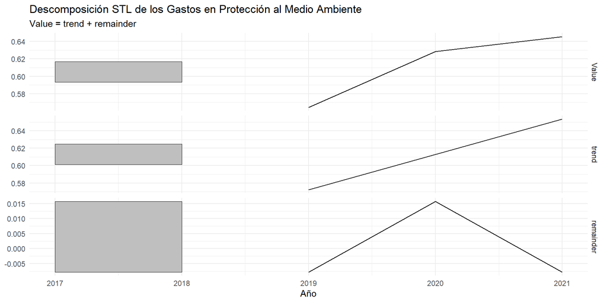

Al aplicar la descomposición STL, se puede observar claramente la tendencia creciente.

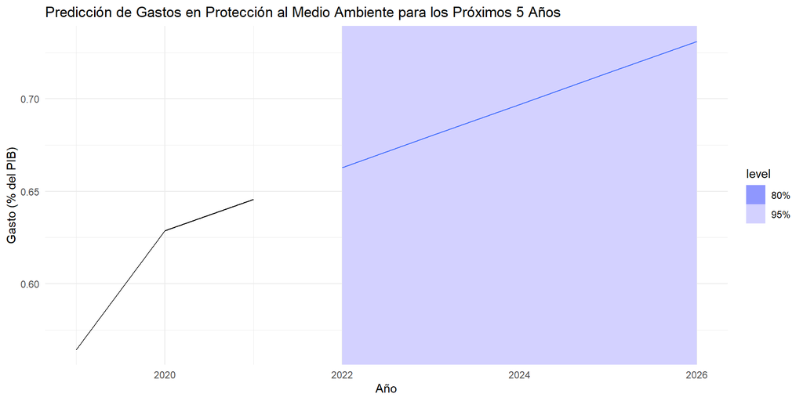

La predicción generada por el modelo ARIMA para los gastos en protección al medio ambiente muestra una línea ascendente en los próximos años, lo que sugiere que, a medida que avanzamos en el tiempo, se espera un aumento sostenido en los recursos destinados a la protección del medio ambiente.

El modelo ARIMA, al proyectar esta línea ascendente, refleja una continuidad en las políticas de inversión ambiental, con la esperanza de que los países sigan aumentando sus presupuestos para abordar la crisis climática global.

## 6.5 Comparación de atributos

El análisis mediante diagramas de dispersión entre los atributos seleccionados, nos permite visualizar cómo se distribuyen los datos y detectar posibles patrones en los gastos gubernamentales a nivel mundial. Sin embargo, es importante destacar que, aunque en los gráficos se puedan observar ciertas tendencias o correlaciones, desde un punto de vista lógico y técnico, estos atributos no tienen una relación causal directa entre sí, ya que pertenecen a áreas muy distintas dentro de las políticas públicas y la asignación de recursos del gobierno. Por ello, hemos hecho cuatro pruebas diferentes para demostrarlo.

[interactive chart not shown]

En primer lugar, la defensa y la protección del medio ambiente representan áreas con necesidades y objetivos completamente diferentes. Los gastos en defensa están generalmente asociados a la seguridad nacional, las relaciones internacionales y las amenazas geopolíticas, mientras que los gastos en protección del medio ambiente buscan mitigar el impacto ecológico, promover el desarrollo sostenible y garantizar la calidad de vida futura de la población. Aunque en algunos contextos ambos pueden ser impulsados por factores externos, como las políticas internacionales o el cambio climático, no existe una correlación directa, ya que los factores que determinan el presupuesto de defensa suelen estar más vinculados a la situación geopolítica, mientras que los gastos en medio ambiente dependen de las prioridades nacionales en términos de sostenibilidad y cambio climático.

[interactive chart not shown]

Por otro lado, la salud y la educación son dos áreas que a menudo pueden mostrar correlaciones parciales debido a que ambos sectores son considerados prioritarios en el bienestar social y se benefician de enfoques similares en términos de inversión en capital humano y desarrollo social. Sin embargo, la asignación presupuestaria a cada uno depende de factores específicos de cada país, como su sistema sanitario, su nivel de desarrollo y las necesidades demográficas. Por ejemplo, países con una población envejecida, como Japón, pueden dedicar un mayor porcentaje de su presupuesto a la salud, mientras que naciones con una población joven podrían priorizar la educación.

[interactive chart not shown]

A pesar de que defensa y salud son áreas muy distintas, pueden influirse mutuamente en situaciones específicas. Durante conflictos bélicos o tensiones geopolíticas, los recursos destinados a la defensa tienden a aumentar, lo que puede reducir el presupuesto para la salud. Sin embargo, en tiempos de paz, los gobiernos suelen priorizar la salud, ya que afecta directamente al bienestar de la población. Así, aunque se puedan observar algunas correlaciones en datos de países en conflicto, no existe una relación causal directa entre ambos sectores.

[interactive chart not shown]

La relación entre educación y protección del medio ambiente está más asociada a la concientización social y el fomento de políticas sostenibles. La educación ambiental tiene un impacto directo en la sensibilización sobre el cambio climático y las prácticas ecológicas, lo que puede incentivar mayores inversiones en la protección del medio ambiente. Sin embargo, aunque ambos sectores pueden estar alineados en políticas sostenibles, los presupuestos de educación y medio ambiente no siempre se ven directamente reflejados entre sí en los diagramas de dispersión, ya que responden a necesidades diferentes.

En resumen, el análisis de los gastos en estas áreas mediante diagramas de dispersión puede ayudar a identificar tendencias y comparaciones visuales, pero es crucial interpretar estos resultados con cautela, reconociendo que las correlaciones observadas no reflejan necesariamente una relación directa entre los atributos, sino que responden a contextos políticos, sociales y económicos particulares de cada nación.

## 6.6 Matriz de correlación

[interactive chart not shown]

Una matriz de correlación es una herramienta estadística utilizada para mostrar la relación entre varias variables. En ella, cada elemento de la matriz indica el grado de correlación entre dos variables específicas. La correlación mide la fuerza y la dirección de la relación lineal entre dos variables, con valores que van desde -1 hasta 1:

- -1 indica una correlación negativa perfecta, lo que significa que las dos variables se mueven en direcciones opuestas (cuando una aumenta, la otra disminuye).
- 0 indica sin correlación lineal, lo que significa que no hay una relación lineal clara entre las variables
- 1 indica una correlación positiva perfecta, lo que significa que ambas variables se mueven juntas en la misma dirección (cuando una aumenta, la otra también lo hace).

De la exploración de los valores de correlación, observamos, que Salud (Health) y Educación (Education) están bastante relacionadas, que Defensa (Defence) y Educación (Education) están muy poco relacionadas con el resto de variables y que Salud ( Health) y Defensa (Defence) tienen una correlación ligeramente negativa.

## 6.7 Componentes principales y visualización

El análisis de componentes principales, ACP, transforma las variables en otras nuevas, haciendo combinaciones lineales de las iniciales. El objetivo principal del ACP es reducir la dimensionalidad quedándonos con las primeras componentes principales que acumulan mayor varianza y desechando el resto.

El criterio para decidir con cuantas componentes principales nos quedamos se basa justamente en el análisis de su varianza. Normalmente se analiza la varianza de las componentes principales en términos relativos, es decir el porcentaje que representa la varianza de respecto a la varianza global dada por la suma de todas las varianzas. Para visualizar esto, utilizamos un gráfico de barras interactivo.

[interactive chart not shown]

Por ejemplo, nos quedaremos con las componentes principales que acumulen más de un 20% de la varianza explicada.

[interactive chart not shown]

Esta gráfica es una representación bidimensional del Análisis de Componentes Principales (ACP).

**Puntos Azules (Observations):** Representan a diferentes países. Cada país se ubica en el gráfico en función de sus valores proyectados sobre los dos primeros componentes principales:

- Eje X (PC1): Corresponde al primer componente principal, que es la combinación lineal de las variables originales que explica la mayor parte de la varianza de los datos.
- Eje Y (PC2): Corresponde al segundo componente principal, que explica la segunda mayor proporción de la varianza no explicada por el primer componente.

La posición de cada punto refleja similitudes o diferencias entre los países en función de las variables originales. Por ejemplo:

- Países cercanos tienen perfiles similares en cuanto a las variables analizadas.
- Países más alejados tienen perfiles diferentes.

**Vectores de Colores (Defence, Education, Environment Protection, Health):** Las líneas de colores representan las variables originales (como gasto en defensa, educación, protección ambiental y salud), y su dirección e intensidad en el gráfico indican:

- Dirección del vector: Hacia dónde aumenta el valor de la variable.
- Longitud del vector: Qué tan importante es esa variable en la varianza explicada por los componentes principales. Un vector más largo indica que esa variable tiene un mayor peso en la configuración de esos componentes.

**Interpretación General:**

- Los países alineados en la dirección de un vector específico (por ejemplo, Education) tienden a tener valores altos en esa variable.
- Si dos vectores están en direcciones similares, esas variables están correlacionadas positivamente.
- Si los vectores están en direcciones opuestas, las variables están negativamente correlacionadas.
- Los países como Croacia o Armenia, que se encuentran alejados del centro, tienen perfiles más extremos en relación a los componentes analizados, mientras que países como Kiribati y Estados Unidos podrían tener perfiles más neutrales o balanceados.

**Ejemplos de Interpretación Específica:**

Croacia se encuentra en la esquina superior derecha, lo que podría sugerir que tiene valores altos en variables que se alinean con los vectores cercanos a esa dirección. Israel y Armenia, ubicados en la parte inferior derecha, pueden estar asociados negativamente con las variables alineadas en la dirección opuesta de los vectores de mayor impacto.

## 6.8 Cuadro de mandos

Un Cuadro de Mandos es una herramienta visual que reúne información clave para evaluar el rendimiento de una organización o proyecto. Muestra datos importantes de forma sencilla, facilitando la toma de decisiones y el seguimiento de objetivos.

**Comparación Mundial**

Este apartado te permite explorar cómo se distribuyen los gastos en diferentes indicadores como defensa, salud, educación o protección ambiental a nivel mundial. Puedes seleccionar un año y el tipo de dato que deseas visualizar (en dólares o como porcentaje del PIB). Al hacerlo, el mapa se colorea automáticamente, mostrando las diferencias de inversión entre países y facilitando la comparación visual de los gastos a nivel global.

**Mayores Inversiones**

Aquí puedes identificar qué países invierten más en un área específica. Al seleccionar un indicador, un año y el tipo de dato, el gráfico de barras muestra una lista de países ordenados según sus niveles de inversión. Esto te permite observar de forma rápida y clara cuáles son los líderes en inversión en cada categoría seleccionada.

**Comparación de Atributos por País**

Este apartado se centra en la evolución histórica de un país específico. Puedes elegir un país, dos años y el tipo de dato, lo que te permitirá visualizar cómo ha cambiado el gasto a lo largo del tiempo. Es una forma efectiva de analizar el progreso o la tendencia de un país en varios indicadores.

**Comparación de Atributos y Países**

Aquí puedes comparar cómo dos países distintos se relacionan entre sí, teniendo e cuenta los diferentes indicadores durante un mismo período de tiempo. Permite seleccionar el año inicial y final y el tipo de dato. El gráfico de dispersión facilita la visualización de patrones o correlaciones entre los países seleccionados, proporcionando una visión clara de las relaciones entre las distintas áreas de gasto.

**Predicciones**

Este apartado utiliza un modelo estadístico avanzado (ARIMA) para proyectar cómo evolucionarán los gastos en los próximos 5 años. Puedes seleccionar un indicador, un país o el promedio global y dos años (inicio y fin) para ver las predicciones. Esto permite anticipar cómo podrían cambiar las inversiones futuras en áreas como defensa, salud, educación o protección ambiental.

**Comparación de Atributos**

Este bloque permite visualizar cómo han variado los gastos en diferentes atributos dentro de un mismo país a lo largo del tiempo. Se seleccionan dos atributos (con posibilidad de cambiar su escala), un año y el tipo de dato. Al observar estas tendencias, podrás identificar cómo cambian las prioridades de inversión en un país y cómo se han comportado los distintos indicadores durante el periodo seleccionado.

**Matriz de Correlación**

Este apartado muestra la relación entre diferentes indicadores, se permitirá seleccionart el tipo de dato y un año. Cada valor en la matriz indica cómo dos variables están relacionadas entre sí: si tienen una correlación positiva (cuando ambas aumentan o disminuyen juntas), negativa (cuando una aumenta y la otra disminuye) o si no existe relación significativa. Es una herramienta clave para comprender cómo interactúan los distintos tipos de gasto entre sí.

**PCA (Análisis de Componentes Principales)**

El PCA es una técnica estadística que simplifica los datos reduciendo su complejidad. Toma múltiples indicadores y los transforma en un conjunto más pequeño de factores principales, que representan la mayor parte de la variabilidad en los datos. Esto facilita la comprensión de grandes volúmenes de información de forma más clara y concisa.

**Visualización 2D PCA**

Esta visualización proyecta los resultados del PCA en un gráfico bidimensional. Al hacerlo, puedes identificar patrones, agrupaciones y tendencias entre países, permitiendo observar cómo se distribuyen los datos en función de los indicadores seleccionados. Es una forma efectiva de detectar similitudes o diferencias significativas entre países en un espacio visual más simple.

# 7 Conclusiones

## 7.1 Resultados y Conclusiones Obtenidas

A lo largo de este proyecto, hemos analizado los gastos gubernamentales en diferentes áreas clave (Defensa, Salud, Educación y Protección del Medio Ambiente) a nivel mundial entre los años 2000 y 2021. Mediante técnicas de análisis exploratorio, diagramas de dispersión, mapas de calor, análisis de componentes principales (PCA) y series temporales (STL y ARIMA), hemos identificado patrones y tendencias que ofrecen una visión profunda de la evolución del gasto público en estas categorías. Los resultados muestran un aumento general en el gasto en Salud, especialmente a partir de 2019, reflejando el impacto de la pandemia de COVID-19 en la priorización de este sector. La Educación ha mantenido un crecimiento estable, aunque con menor aceleración comparada con la Salud, probablemente debido a los ajustes fiscales posteriores a la [crisis financiera](https://es.wikipedia.org/wiki/Crisis_financiera_de_2007-2008) de 2008. Por otro lado, la inversión en Protección del Medio Ambiente ha mostrado un crecimiento más modesto, pero con un repunte desde 2015, en línea con el aumento de la conciencia climática a nivel global. Finalmente, el gasto en Defensa presenta variaciones más marcadas, respondiendo a contextos políticos y conflictos internacionales.

## 7.2 Grado de Consecución de los Objetivos

El proyecto ha cumplido con éxito los objetivos planteados inicialmente:

1. Análisis Comparativo: Se ha logrado realizar un análisis detallado de los gastos gubernamentales, permitiendo comparar tendencias y variaciones entre distintos países y períodos.
2. Visualización y Análisis de Tendencias: A través del uso de técnicas estadísticas avanzadas y visualizaciones interactivas, hemos proporcionado una visión clara y comprensible de los datos, destacando patrones importantes y eventos que influyeron significativamente en el gasto público.
3. Modelo Predictivo: La implementación de modelos de series temporales (ARIMA) ha permitido realizar predicciones sobre la evolución futura del gasto, aunque con ciertas limitaciones debido a la alta variabilidad introducida por eventos inesperados como la pandemia.

## 7.3 Posibles Extensiones y Trabajos Futuros

Este análisis podría extenderse en varias direcciones para obtener una comprensión más profunda y responder a nuevas preguntas de investigación:

1. Incorporación de Nuevas Variables: Integrar datos adicionales y otras variables macroeconómicas podría ayudar a comprender mejor las decisiones de gasto de los gobiernos y su relación con el crecimiento económico.
2. Análisis Regional Más Detallado: Realizar un análisis más específico por regiones o bloques económicos (por ejemplo, Unión Europea, Asia-Pacífico) para identificar diferencias intra-regionales y sus posibles causas.
3. Modelos Predictivos Más Complejos: Se podrían explorar modelos predictivos más sofisticados como los modelos estructurales y redes neuronales recurrentes (RNN) para mejorar la precisión de las predicciones a futuro, especialmente en series con alta variabilidad como el gasto en salud.
4. Estudio del Impacto Político: Investigar cómo los cambios en los gobiernos y políticas públicas afectan el gasto en estas áreas, analizando períodos pre y post elecciones o cambios de administración.

En conclusión, este proyecto ha proporcionado un análisis completo y riguroso de los patrones de gasto gubernamental a lo largo del tiempo, ofreciendo tanto una visión histórica como una perspectiva de futuro. Las herramientas y métodos utilizados han demostrado ser efectivos para identificar tendencias y correlaciones, pero también han resaltado la necesidad de una investigación continua para entender plenamente los factores que influyen en las decisiones de gasto público.